# Factor Analysis (Wave 1) – Dads Matter

Michael Wu

2023-10-24

# 1 Recommendations

- MOTHER AND FATHER INVOLVEMENT WITH INFANT (`mfi`): Good CFA fit and use factor scores generated from CFA model
- PARENT-CHILD CONFLICT TACTICS SCALES (`pccts`): Use scoring rule and sum scores (The midpoints are the same as the response category numbers for categories 0, 1, and 2. For category 3 (3–5 times) the midpoint is 4, for category 4 (6–10 times) it is 8, for category 5 (11–20 times) it is 15, and for category 6 (More than 20 times in the past year) we suggest using 25 as the midpoint.)
- CHILD NEGLECT (`neg`): Use sum scores
- DEPRESSION: CIDI-SF: Use scoring rules (*unclear which version we are using*)
- PARENTING ALLIANCE INVENTORY (`pai`):
  - Mother’s self-report: Questionable CFA model fit
  - Father’s self-report: Good CFA fit and use factor score
- RELATIONSHIP QUALITY (`rq`): Good CFA fit and use factor score
- CONFLICT TACTICS SCALE (`cts`): Use item-pair sum/average score

# 2 Introduction

**Evidence of construct validity:**

**Evidence of internal consistency:**

- Cronbach’s Alpha (α) is a measure of internal consistency reliability that assesses the extent to which items within a test or questionnaire are inter-related, calculated as the mean of all possible split-half reliabilities, corrected for test length.
- McDonald’s Omega (ω) is a measure of internal consistency reliability based on the factor structure of the test, calculated by decomposing the total variance of the items into the variance due to a general factor, the variance due to group factors, and the unique variance, providing a more accurate estimate of reliability when the assumption of unidimensionality is violated.
- Simply put, α is computed based on the raw data, and ω is computed from the CFA. In practice, we would often want to calculate a reliability coefficient for each subscale at each wave when we build a multi-factor CFA, besides a general reliability coefficient for the entire construct.

# 3 Data Preparation

```r
# load library
library(tidyverse)
library(lavaan)
library(psych)
source(here::here("R/functions.R"))

# manually change this to the box path on your computer if using Windows
box_path <- "~/Library/CloudStorage/Box-Box/Dads Matter Project"

# load data
dat_s <- read_csv(file.path(box_path, "Data analysis/data/dads_matter_fa.csv"))
```

**_m: mother report**

**_f: father report**

# 4 MOTHER AND FATHER INVOLVEMENT WITH INFANT

Based on modification indices, for all four models below (father/mother report on self or other parent’s involvement), we added the following residual covariance terms to the latent factor model. The reason to add these terms are:

- There might be a theoretical reason to believe that two indicators share variance above and beyond what is explained by the latent factors.
- Modifications to the CFA models improved their fit to the data.

Specifically, we added residual covariance between `mfi3` (Read stories to (CHILD)) and `mfi4` (Tell stories to (CHILD)) because of the literal similarity between the two items.

We also added a residual covariance between `mfi7` (Hug or show physical affection to (CHILD)) and `mfi8` (Put (CHILD) to bed) because both actions involve physical affection.

## 4.1 Father’s involvement with children (reported by mothers)

```r
cfa_mfi_m <- '
  mfi_m_1 =~ mfi1.1_1 + mfi2.1_1 + mfi3.1_1 + mfi4.1_1 +
           mfi5.1_1 + mfi6.1_1 + mfi7.1_1 + mfi8.1_1

  mfi3.1_1 ~~ mfi4.1_1
  mfi7.1_1 ~~ mfi8.1_1
'

fit_mfi_m <- cfa(cfa_mfi_m,
                 data = dat_s,
                 std.lv = TRUE, missing = "FIML",
                 parameterization = "theta"
                 )
```

**Click to see full model results:**

```r
summary(fit_mfi_m, fit.measures = TRUE, standardized = TRUE)
```

```
## lavaan 0.6.15 ended normally after 37 iterations
##
##   Estimator                                         ML
##   Optimization method                           NLMINB
##   Number of model parameters                        26
##
##                                                   Used       Total
##   Number of observations                           150         204
##   Number of missing patterns                         8
##
## Model Test User Model:
##
##   Test statistic                                25.167
##   Degrees of freedom                                18
##   P-value (Chi-square)                           0.120
##
## Model Test Baseline Model:
##
##   Test statistic                               264.106
##   Degrees of freedom                                28
##   P-value                                        0.000
##
## User Model versus Baseline Model:
##
##   Comparative Fit Index (CFI)                    0.970
##   Tucker-Lewis Index (TLI)                       0.953
##
##   Robust Comparative Fit Index (CFI)             0.970
##   Robust Tucker-Lewis Index (TLI)                0.953
##
## Loglikelihood and Information Criteria:
##
##   Loglikelihood user model (H0)              -2592.992
##   Loglikelihood unrestricted model (H1)      -2580.408
##
##   Akaike (AIC)                                5237.983
##   Bayesian (BIC)                              5316.260
##   Sample-size adjusted Bayesian (SABIC)       5233.975
##
## Root Mean Square Error of Approximation:
```

[output cut: 50 more lines]

```
##    .mfi7.1_1          6.407    0.130   49.416    0.000    6.407    4.035
##    .mfi8.1_1          4.940    0.206   24.010    0.000    4.940    1.960
##     mfi_m_1           0.000                               0.000    0.000
##
## Variances:
##                    Estimate  Std.Err  z-value  P(>|z|)   Std.lv  Std.all
##    .mfi1.1_1          2.178    0.479    4.544    0.000    2.178    0.372
##    .mfi2.1_1          4.673    0.629    7.432    0.000    4.673    0.691
##    .mfi3.1_1          4.426    0.571    7.750    0.000    4.426    0.754
##    .mfi4.1_1          5.719    0.714    8.010    0.000    5.719    0.808
##    .mfi5.1_1          5.161    0.702    7.355    0.000    5.161    0.660
##    .mfi6.1_1          4.836    0.580    8.340    0.000    4.836    0.920
##    .mfi7.1_1          1.958    0.248    7.895    0.000    1.958    0.777
##    .mfi8.1_1          4.354    0.589    7.395    0.000    4.354    0.686
##     mfi_m_1           1.000                               1.000    1.000
```

```r
# modindices(fit_mfi_m, sort = TRUE, maximum.number = 5)
```

**Reliability:**

```r
get_rel(model = fit_mfi_m,
        data = dat_s |> select(mfi1.1_1:mfi8.1_1))
```

```
## [1] "Cronbach's Alpha is 0.766, which is Acceptable; McDonald's Omega is 0.723, which is Acceptable."
```

## 4.2 Mother’s involvement with children (reported by mothers)

```r
cfa_mfia_m <- '
  mfia_m_1 =~ mfi1a.1_1 + mfi2a.1_1 + mfi3a.1_1 + mfi4a.1_1 +
           mfi5a.1_1 + mfi6a.1_1 + mfi7a.1_1 + mfi8a.1_1

  mfi3a.1_1 ~~ mfi4a.1_1
  mfi7a.1_1 ~~ mfi8a.1_1
'

fit_mfia_m <- cfa(cfa_mfia_m,
                 data = dat_s,
                 std.lv = TRUE, missing = "FIML",
                 parameterization = "theta"
                 )
```

**Click to see full model results:**

```r
summary(fit_mfia_m, fit.measures = TRUE, standardized = TRUE)
```

```
## lavaan 0.6.15 ended normally after 43 iterations
##
##   Estimator                                         ML
##   Optimization method                           NLMINB
##   Number of model parameters                        26
##
##                                                   Used       Total
##   Number of observations                           149         204
##   Number of missing patterns                         1
##
## Model Test User Model:
##
##   Test statistic                                22.983
##   Degrees of freedom                                18
##   P-value (Chi-square)                           0.191
##
## Model Test Baseline Model:
##
##   Test statistic                               197.591
##   Degrees of freedom                                28
##   P-value                                        0.000
##
## User Model versus Baseline Model:
##
##   Comparative Fit Index (CFI)                    0.971
##   Tucker-Lewis Index (TLI)                       0.954
##
##   Robust Comparative Fit Index (CFI)             0.971
##   Robust Tucker-Lewis Index (TLI)                0.954
##
## Loglikelihood and Information Criteria:
##
##   Loglikelihood user model (H0)              -2245.711
##   Loglikelihood unrestricted model (H1)      -2234.219
##
##   Akaike (AIC)                                4543.421
##   Bayesian (BIC)                              4621.524
##   Sample-size adjusted Bayesian (SABIC)       4539.241
##
## Root Mean Square Error of Approximation:
```

[output cut: 50 more lines]

```
##    .mfi7a.1_1         6.946    0.031  222.849    0.000    6.946   18.256
##    .mfi8a.1_1         6.725    0.077   87.306    0.000    6.725    7.152
##     mfia_m_1          0.000                               0.000    0.000
##
## Variances:
##                    Estimate  Std.Err  z-value  P(>|z|)   Std.lv  Std.all
##    .mfi1a.1_1         2.317    0.431    5.378    0.000    2.317    0.568
##    .mfi2a.1_1         3.340    0.468    7.138    0.000    3.340    0.775
##    .mfi3a.1_1         4.990    0.794    6.282    0.000    4.990    0.677
##    .mfi4a.1_1         5.963    0.810    7.358    0.000    5.963    0.784
##    .mfi5a.1_1         4.251    0.724    5.869    0.000    4.251    0.596
##    .mfi6a.1_1         6.081    0.706    8.612    0.000    6.081    0.995
##    .mfi7a.1_1         0.137    0.016    8.407    0.000    0.137    0.944
##    .mfi8a.1_1         0.843    0.100    8.429    0.000    0.843    0.953
##     mfia_m_1          1.000                               1.000    1.000
```

```r
# modindices(fit_mfia_m, sort = TRUE, maximum.number = 5)
```

**Reliability:**

```r
get_rel(model = fit_mfia_m,
        data = dat_s |> select(mfi1a.1_1:mfi8a.1_1))
```

```
## [1] "Cronbach's Alpha is 0.647, which is Acceptable; McDonald's Omega is 0.615, which is Acceptable."
```

```r
cfa_mfi_f <- '
  mfi_f_1 =~ mfi1.2_1 + mfi2.2_1 + mfi3.2_1 + mfi4.2_1 +
           mfi5.2_1 + mfi6.2_1 + mfi7.2_1 + mfi8.2_1

  mfi3.2_1 ~~ mfi4.2_1
  mfi7.2_1 ~~ mfi8.2_1
'

fit_mfi_f <- cfa(cfa_mfi_f,
                 data = dat_s,
                 std.lv = TRUE, missing = "FIML",
                 parameterization = "theta"
                 )
```

**Click to see full model results:**

```r
summary(fit_mfi_f, fit.measures = TRUE, standardized = TRUE)
```

```
## lavaan 0.6.15 ended normally after 35 iterations
##
##   Estimator                                         ML
##   Optimization method                           NLMINB
##   Number of model parameters                        26
##
##                                                   Used       Total
##   Number of observations                           183         204
##   Number of missing patterns                        10
##
## Model Test User Model:
##
##   Test statistic                                38.886
##   Degrees of freedom                                18
##   P-value (Chi-square)                           0.003
##
## Model Test Baseline Model:
##
##   Test statistic                               462.969
##   Degrees of freedom                                28
##   P-value                                        0.000
##
## User Model versus Baseline Model:
##
##   Comparative Fit Index (CFI)                    0.952
##   Tucker-Lewis Index (TLI)                       0.925
##
##   Robust Comparative Fit Index (CFI)             0.953
##   Robust Tucker-Lewis Index (TLI)                0.927
##
## Loglikelihood and Information Criteria:
##
##   Loglikelihood user model (H0)              -3066.395
##   Loglikelihood unrestricted model (H1)      -3046.952
##
##   Akaike (AIC)                                6184.791
##   Bayesian (BIC)                              6268.237
##   Sample-size adjusted Bayesian (SABIC)       6185.890
##
## Root Mean Square Error of Approximation:
```

[output cut: 50 more lines]

```
##    .mfi7.2_1          6.304    0.126   50.194    0.000    6.304    3.717
##    .mfi8.2_1          4.824    0.185   26.127    0.000    4.824    1.935
##     mfi_f_1           0.000                               0.000    0.000
##
## Variances:
##                    Estimate  Std.Err  z-value  P(>|z|)   Std.lv  Std.all
##    .mfi1.2_1          2.532    0.401    6.310    0.000    2.532    0.423
##    .mfi2.2_1          3.612    0.489    7.390    0.000    3.612    0.525
##    .mfi3.2_1          3.553    0.430    8.256    0.000    3.553    0.692
##    .mfi4.2_1          3.538    0.444    7.961    0.000    3.538    0.622
##    .mfi5.2_1          4.759    0.568    8.385    0.000    4.759    0.673
##    .mfi6.2_1          5.406    0.591    9.154    0.000    5.406    0.868
##    .mfi7.2_1          1.829    0.229    8.003    0.000    1.829    0.636
##    .mfi8.2_1          3.914    0.481    8.130    0.000    3.914    0.630
##     mfi_f_1           1.000                               1.000    1.000
```

```r
# modindices(fit_mfi_f, sort = TRUE, maximum.number = 5)
```

**Reliability:**

```r
get_rel(model = fit_mfi_f,
        data = dat_s |> select(mfi1.2_1:mfi8.2_1))
```

```
## [1] "Cronbach's Alpha is 0.817, which is Good; McDonald's Omega is 0.79, which is Acceptable."
```

## 4.4 Mother’s involvement with children (reported by fathers)

```r
cfa_mfia_f <- '
  mfia_f_1 =~ mfi1a.2_1 + mfi2a.2_1 + mfi3a.2_1 + mfi4a.2_1 +
           mfi5a.2_1 + mfi6a.2_1 + mfi7a.2_1 + mfi8a.2_1

  mfi3a.2_1 ~~ mfi4a.2_1
  mfi7a.2_1 ~~ mfi8a.2_1
'

fit_mfia_f <- cfa(cfa_mfia_f,
                 data = dat_s,
                 std.lv = TRUE, missing = "FIML",
                 parameterization = "theta"
                 )
```

**Click to see full model results:**

```r
summary(fit_mfia_f, fit.measures = TRUE, standardized = TRUE)
```

```
## lavaan 0.6.15 ended normally after 40 iterations
##
##   Estimator                                         ML
##   Optimization method                           NLMINB
##   Number of model parameters                        26
##
##                                                   Used       Total
##   Number of observations                           183         204
##   Number of missing patterns                         2
##
## Model Test User Model:
##
##   Test statistic                                21.048
##   Degrees of freedom                                18
##   P-value (Chi-square)                           0.277
##
## Model Test Baseline Model:
##
##   Test statistic                               351.002
##   Degrees of freedom                                28
##   P-value                                        0.000
##
## User Model versus Baseline Model:
##
##   Comparative Fit Index (CFI)                    0.991
##   Tucker-Lewis Index (TLI)                       0.985
##
##   Robust Comparative Fit Index (CFI)             0.991
##   Robust Tucker-Lewis Index (TLI)                0.986
##
## Loglikelihood and Information Criteria:
##
##   Loglikelihood user model (H0)              -2859.923
##   Loglikelihood unrestricted model (H1)      -2849.398
##
##   Akaike (AIC)                                5771.845
##   Bayesian (BIC)                              5855.292
##   Sample-size adjusted Bayesian (SABIC)       5772.945
##
## Root Mean Square Error of Approximation:
```

[output cut: 50 more lines]

```
##    .mfi7a.2_1         6.820    0.066  102.916    0.000    6.820    7.608
##    .mfi8a.2_1         6.475    0.102   63.739    0.000    6.475    4.712
##     mfia_f_1          0.000                               0.000    0.000
##
## Variances:
##                    Estimate  Std.Err  z-value  P(>|z|)   Std.lv  Std.all
##    .mfi1a.2_1         2.115    0.331    6.387    0.000    2.115    0.518
##    .mfi2a.2_1         2.103    0.319    6.592    0.000    2.103    0.531
##    .mfi3a.2_1         3.899    0.499    7.812    0.000    3.899    0.668
##    .mfi4a.2_1         4.392    0.551    7.970    0.000    4.392    0.701
##    .mfi5a.2_1         4.923    0.561    8.777    0.000    4.923    0.811
##    .mfi6a.2_1         5.871    0.633    9.280    0.000    5.871    0.942
##    .mfi7a.2_1         0.621    0.072    8.598    0.000    0.621    0.773
##    .mfi8a.2_1         1.651    0.182    9.055    0.000    1.651    0.874
##     mfia_f_1          1.000                               1.000    1.000
```

```r
# modindices(fit_mfia_f, sort = TRUE, maximum.number = 5)
```

**Reliability:**

```r
get_rel(model = fit_mfia_f,
        data = dat_s |> select(mfi1a.2_1:mfi8a.2_1))
```

```
## [1] "Cronbach's Alpha is 0.731, which is Acceptable; McDonald's Omega is 0.675, which is Acceptable."
```

# 5 PARENT-CHILD CONFLICT TACTICS SCALES

Straus, M. A., Hamby, S. L., Finkelhor, D., Moore, D. W., & Runyan, D. (1998). Identification of child maltreatment with the Parent-Child Conflict Tactics Scales: Development and psychometric data for a national sample of American parents. Child abuse & neglect, 22(4), 249-270. https://doi.org/10.1016/S0145-2134(97)00174-9

This scale has existing scoring rules (https://emerge.ucsd.edu/r_3dl0y438y6yhvyo/):

The scale is scored by adding the midpoints for the response categories chosen by the participant. The midpoints are the same as the response category numbers for categories 0, 1, and 2. For category 3 (3–5 times) the midpoint is 4, for category 4 (6–10 times) it is 8, for category 5 (11–20 times) it is 15, and for category 6 (More than 20 times in the past year) we suggest using 25 as the midpoint.

As described in the original paper, some events measured by the scale are very rare, thus resulting a very skewed distribution: “The extremely skewed distributions drastically lower the correlation between the items and reduces alpha because alpha is a function of the size of the correlations between items. In addition the severe assault items do not meet other assumptions such as equal variance.” Therefore, we are following the original recommended scoring rules instead of building new CFAs on this established measure (which failed to build due to highly skewed data).

```r
dat_s <- dat_s |>
  mutate(
    across(starts_with("pccts"), ~ case_when(
      .x == 3  ~ 4,
      .x == 4  ~ 8,
      .x == 5  ~ 15,
      .x == 6  ~ 25,
      TRUE     ~ .x
    ))
  )
```

# 6 CHILD NEGLECT

For this measure, the CFA models also failed to build due to highly skewed data. I am not sure what the original paper is and what it suggests, but similar to PCCTS, we can take a sum of these variables as the total instances of child neglect, instead of treating it as a latent construct.

# 7 DEPRESSION: CIDI-SF

This scale has conditional questions that prompt you to skip a few questions based on your choice in previous questions. Therefore, some later questions only have very few respondent, so CFA is not a good option for this scale.

According to the manual, there are two ways of scoring the scale: https://www.hcp.med.harvard.edu/ncs/ftpdir/cidisf_readme.pdf

Kessler, R. C., Andrews, G., Mroczek, D., Ustun, B., & Wittchen, H. U. (1998). The World Health Organization composite international diagnostic interview short‐form (CIDI‐SF). International journal of methods in psychiatric research, 7(4), 171-185.

But I am not sure why there are 13 items in our study. Past studies seem to suggest 6-item or 10-item versions.

# 8 PARENTING ALLIANCE INVENTORY

## 8.1 Mother’s self-report parenting alliance with father

Based on Aaron’s notes, there seem to be two theory-based factors for this measure: alliance with partner and shared alliance. However, the CFA model for mother’s self-report does not have acceptable fit indices and data-driven modification indices do not seem to suggest theoretically sound alternative links.

```r
# Theory-based 2-factor model does not fit well and there is no theoretical justification for the links suggested by modification indices

cfa_pai_m <- '
  pai_shared_m_1 =~ pai5.1_1 + pai7.1_1 + pai9.1_1 + pai12.1_1 + pai17.1_1 + pai23.1_1 + pai24.1_1 + pai25.1_1
  pai_partner_m_1 =~ pai13.1_1 + pai14.1_1 + pai19.1_1 + pai20.1_1 + pai21.1_1 + pai27.1_1 + pai27.1_1 + pai28.1_1 + pai29.1_1
'


fit_pai_m <- cfa(cfa_pai_m,
                 data = dat_s,
                 std.lv = TRUE, missing = "FIML",
                 parameterization = "theta"
                 )
```

**Click to see full model results:**

```r
summary(fit_pai_m, fit.measures = TRUE, standardized = TRUE)
```

```
## lavaan 0.6.15 ended normally after 78 iterations
##
##   Estimator                                         ML
##   Optimization method                           NLMINB
##   Number of model parameters                        49
##
##   Number of observations                           204
##   Number of missing patterns                         7
##
## Model Test User Model:
##
##   Test statistic                               316.209
##   Degrees of freedom                               103
##   P-value (Chi-square)                           0.000
##
## Model Test Baseline Model:
##
##   Test statistic                              1870.730
##   Degrees of freedom                               120
##   P-value                                        0.000
##
## User Model versus Baseline Model:
##
##   Comparative Fit Index (CFI)                    0.878
##   Tucker-Lewis Index (TLI)                       0.858
##
##   Robust Comparative Fit Index (CFI)             0.868
##   Robust Tucker-Lewis Index (TLI)                0.847
##
## Loglikelihood and Information Criteria:
##
##   Loglikelihood user model (H0)              -2368.584
##   Loglikelihood unrestricted model (H1)      -2210.479
##
##   Akaike (AIC)                                4835.168
##   Bayesian (BIC)                              4997.756
##   Sample-size adjusted Bayesian (SABIC)       4842.510
##
## Root Mean Square Error of Approximation:
##
```

[output cut: 74 more lines]

```
##    .pai12.1_1         0.175    0.022    8.095    0.000    0.175    0.381
##    .pai17.1_1         0.190    0.021    9.177    0.000    0.190    0.471
##    .pai23.1_1         0.162    0.022    7.306    0.000    0.162    0.274
##    .pai24.1_1         0.182    0.020    9.106    0.000    0.182    0.504
##    .pai25.1_1         0.202    0.023    8.672    0.000    0.202    0.386
##    .pai13.1_1         0.115    0.015    7.668    0.000    0.115    0.371
##    .pai14.1_1         0.693    0.079    8.769    0.000    0.693    0.809
##    .pai19.1_1         0.101    0.013    8.059    0.000    0.101    0.450
##    .pai20.1_1         0.252    0.028    8.994    0.000    0.252    0.534
##    .pai21.1_1         0.449    0.053    8.464    0.000    0.449    0.570
##    .pai27.1_1         0.267    0.032    8.241    0.000    0.267    0.543
##    .pai28.1_1         0.198    0.025    7.984    0.000    0.198    0.453
##    .pai29.1_1         0.312    0.035    9.015    0.000    0.312    0.526
##     pai_shared_m_1    1.000                               1.000    1.000
##     pai_partnr_m_1    1.000                               1.000    1.000
```

```r
# modindices(fit_pai_m, sort = TRUE, maximum.number = 5)
```

We then re-conducted an EFA model to explore the potential factor structure. Based on the eigenvalues, 2-factor model seems to be a better solution.

```r
vec <- grep("^pai\\d+\\.1_1$", names(dat_s), value = T)

# Extract numbers using regular expression
numbers <- as.numeric(gsub("pai([0-9]+)\\..*", "\\1", vec))

# Order the vector based on the extracted numbers
sorted_vec <- vec[order(numbers)]

efa_pai_m <- lavaan::efa(dat_s,
                 ov.names = sorted_vec,
                 nfactors = 1:3
                 )
```

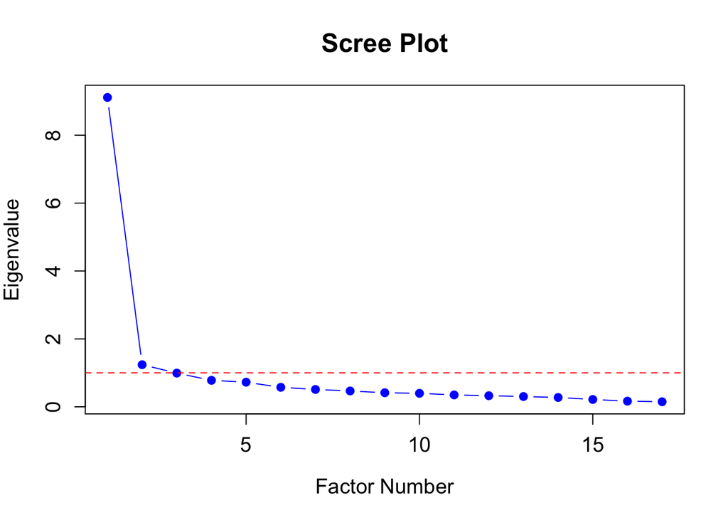

```r
# Eigenvalues extracted from the fitted lavaan EFA model
eigenvalues <- c(9.112, 1.240, 0.993, 0.780, 0.725, 0.574, 0.511, 0.467, 0.414, 0.397, 0.350, 0.327, 0.303, 0.275, 0.216, 0.167, 0.149)

# Create a Scree Plot
plot(eigenvalues, type = "b", pch = 19, main = "Scree Plot",
     xlab = "Factor Number", ylab = "Eigenvalue", col = "blue",
     cex.lab = 1.2, cex.axis = 1.2, cex.main = 1.5)

# Add a reference line at y = 1
abline(h = 1, col = "red", lty = 2)
```

**Click to see full model results:**

```r
# model stats
summary(efa_pai_m)
```

```
##
##   Estimator                                         ML
##   Rotation method                       GEOMIN OBLIQUE
##   Geomin epsilon                                 0.001
##   Rotation algorithm (rstarts)                GPA (30)
##   Standardized metric                             TRUE
##   Row weights                                     None
##
##                                                   Used       Total
##   Number of observations                           159         204
##
## Overview models:
##                     aic      bic    sabic   chisq  df pvalue   cfi rmsea
##   nfactors = 1 4547.530 4651.873 4544.244 369.983 119      0 0.856 0.115
##   nfactors = 2 4471.067 4624.512 4466.234 261.520 103      0 0.909 0.098
##   nfactors = 3 4412.966 4612.445 4406.684 173.419  88      0 0.951 0.078
##
## Eigenvalues correlation matrix:
##
##     ev1     ev2     ev3     ev4     ev5     ev6     ev7     ev8     ev9    ev10
##   9.112   1.240   0.993   0.780   0.725   0.574   0.511   0.467   0.414   0.397
##    ev11    ev12    ev13    ev14    ev15    ev16    ev17
##   0.350   0.327   0.303   0.275   0.216   0.167   0.149
##
## Number of factors:  1
##
## Standardized loadings: (* = significant at 1% level)
##
##               f1       unique.var   communalities
## pai5.1_1   0.721*           0.481           0.519
## pai7.1_1   0.722*           0.478           0.522
## pai9.1_1   0.649*           0.579           0.421
## pai12.1_1  0.786*           0.382           0.618
## pai13.1_1  0.793*           0.372           0.628
## pai14.1_1  0.442*           0.804           0.196
## pai17.1_1  0.735*           0.460           0.540
## pai19.1_1  0.741*           0.451           0.549
## pai20.1_1  0.673*           0.547           0.453
## pai21.1_1  0.678*           0.540           0.460
## pai23.1_1  0.855*           0.269           0.731
```

[output cut: 68 more lines]

```
## pai28.1_1  0.381*      .       .            0.456           0.544
## pai29.1_1      .       .   0.513*           0.405           0.595
##
##                               f2    f1    f3  total
## Sum of sq (obliq) loadings 5.151 3.050 1.944 10.145
## Proportion of total        0.508 0.301 0.192  1.000
## Proportion var             0.303 0.179 0.114  0.597
## Cumulative var             0.303 0.482 0.597  0.597
##
## Factor correlations: (* = significant at 1% level)
##
##        f1      f2      f3
## f1  1.000
## f2  0.779*  1.000
## f3  0.348   0.572   1.000
```

```r
cfa_pai_m <- '
  pai_f1_m_1 =~ pai5.1_1 + pai7.1_1 + pai14.1_1 + pai20.1_1 + pai27.1_1 + pai29.1_1

  pai_f2_m_1 =~ pai9.1_1 + pai12.1_1 + pai13.1_1 + pai17.1_1 + pai19.1_1 + pai21.1_1 + pai23.1_1 + pai24.1_1 + pai25.1_1 + pai26.1_1 + pai28.1_1

  pai13.1_1 ~~ pai19.1_1
'


fit_pai_m <- cfa(cfa_pai_m,
                 data = dat_s,
                 std.lv = TRUE, missing = "FIML",
                 parameterization = "theta"
                 )
```

**Click to see full model results:**

```r
summary(fit_pai_m, fit.measures = TRUE, standardized = TRUE)
```

```
## lavaan 0.6.15 ended normally after 84 iterations
##
##   Estimator                                         ML
##   Optimization method                           NLMINB
##   Number of model parameters                        53
##
##   Number of observations                           204
##   Number of missing patterns                         7
##
## Model Test User Model:
##
##   Test statistic                               292.635
##   Degrees of freedom                               117
##   P-value (Chi-square)                           0.000
##
## Model Test Baseline Model:
##
##   Test statistic                              1999.767
##   Degrees of freedom                               136
##   P-value                                        0.000
##
## User Model versus Baseline Model:
##
##   Comparative Fit Index (CFI)                    0.906
##   Tucker-Lewis Index (TLI)                       0.890
##
##   Robust Comparative Fit Index (CFI)             0.899
##   Robust Tucker-Lewis Index (TLI)                0.883
##
## Loglikelihood and Information Criteria:
##
##   Loglikelihood user model (H0)              -2529.549
##   Loglikelihood unrestricted model (H1)      -2383.232
##
##   Akaike (AIC)                                5165.099
##   Bayesian (BIC)                              5340.959
##   Sample-size adjusted Bayesian (SABIC)       5173.039
##
## Root Mean Square Error of Approximation:
##
```

[output cut: 79 more lines]

```
##    .pai27.1_1         0.283    0.035    8.115    0.000    0.283    0.575
##    .pai29.1_1         0.271    0.033    8.290    0.000    0.271    0.456
##    .pai9.1_1          0.437    0.046    9.521    0.000    0.437    0.576
##    .pai12.1_1         0.185    0.023    8.222    0.000    0.185    0.402
##    .pai13.1_1         0.134    0.016    8.290    0.000    0.134    0.433
##    .pai17.1_1         0.191    0.021    9.219    0.000    0.191    0.474
##    .pai19.1_1         0.115    0.014    8.523    0.000    0.115    0.516
##    .pai21.1_1         0.439    0.051    8.604    0.000    0.439    0.563
##    .pai23.1_1         0.155    0.021    7.341    0.000    0.155    0.264
##    .pai24.1_1         0.175    0.019    9.079    0.000    0.175    0.483
##    .pai25.1_1         0.194    0.022    8.664    0.000    0.194    0.371
##    .pai26.1_1         0.364    0.038    9.590    0.000    0.364    0.607
##    .pai28.1_1         0.220    0.026    8.327    0.000    0.220    0.507
##     pai_f1_m_1        1.000                               1.000    1.000
##     pai_f2_m_1        1.000                               1.000    1.000
```

```r
# modindices(fit_pai_m, sort = TRUE, maximum.number = 5)
```

**Reliability:**

```r
get_rel(model = fit_pai_m,
        data = dat_s |> select(pai7.1_1:pai28.1_1))
```

```
## [1] "Cronbach's Alpha is 0.941, which is Excellent; McDonald's Omega is 0.821, which is Good."
## [2] "Cronbach's Alpha is 0.941, which is Excellent; McDonald's Omega is 0.926, which is Excellent."
```

Given this situation, we may consider the following:

Try to justify the following relationship (beyond what the latent factor structure accounts for). Adding these residual covariances improves the model fit to acceptable (although not great).

- pai13.1_1 (I believe my child’s father is a good parent.) ~~ pai19.1_1 (My child’s father cares about our child.)
- pai5.1_1 (My child’s father sees our child in the same way I do.) ~~ pai24.1_1 (Talking to my child’s father about our child is something I look forward to.)
- pai20.1_1 (I feel good about my child’s father’s judgment about what is right for our child.) ~~ pai29.1_1 (My child’s father knows how to manage children well.)

## 8.2 Father’s self-report parenting alliance with mothers

In contrast to mother’s self-report, father’s self-report fits acceptably, and the fit improves adding the following residual covariance terms.

```r
cfa_pai_f <- '
  pai_shared_m_1 =~ pai5.2_1 + pai7.2_1 + pai9.2_1 + pai12.2_1 + pai17.2_1 + pai23.2_1 + pai24.2_1 + pai25.2_1
  pai_partner_m_1 =~ pai13.2_1 + pai14.2_1 + pai19.2_1 + pai20.2_1 + pai21.2_1 + pai27.2_1 + pai27.2_1 + pai28.2_1 + pai29.2_1

  pai13.2_1 ~~ pai19.2_1
  pai9.2_1 ~~ pai20.2_1
'


fit_pai_f <- cfa(cfa_pai_f,
                 data = dat_s,
                 std.lv = TRUE, missing = "FIML",
                 parameterization = "theta"
                 )
```

**Click to see full model results:**

```r
summary(fit_pai_f, fit.measures = TRUE, standardized = TRUE)
```

```
## lavaan 0.6.15 ended normally after 91 iterations
##
##   Estimator                                         ML
##   Optimization method                           NLMINB
##   Number of model parameters                        51
##
##                                                   Used       Total
##   Number of observations                           186         204
##   Number of missing patterns                         3
##
## Model Test User Model:
##
##   Test statistic                               222.219
##   Degrees of freedom                               101
##   P-value (Chi-square)                           0.000
##
## Model Test Baseline Model:
##
##   Test statistic                              2176.480
##   Degrees of freedom                               120
##   P-value                                        0.000
##
## User Model versus Baseline Model:
##
##   Comparative Fit Index (CFI)                    0.941
##   Tucker-Lewis Index (TLI)                       0.930
##
##   Robust Comparative Fit Index (CFI)             0.941
##   Robust Tucker-Lewis Index (TLI)                0.930
##
## Loglikelihood and Information Criteria:
##
##   Loglikelihood user model (H0)              -2470.329
##   Loglikelihood unrestricted model (H1)      -2359.219
##
##   Akaike (AIC)                                5042.658
##   Bayesian (BIC)                              5207.171
##   Sample-size adjusted Bayesian (SABIC)       5045.635
##
## Root Mean Square Error of Approximation:
```

[output cut: 79 more lines]

```
##    .pai12.2_1         0.152    0.018    8.269    0.000    0.152    0.292
##    .pai17.2_1         0.320    0.035    9.198    0.000    0.320    0.555
##    .pai23.2_1         0.164    0.020    8.038    0.000    0.164    0.257
##    .pai24.2_1         0.206    0.023    9.112    0.000    0.206    0.513
##    .pai25.2_1         0.160    0.020    8.172    0.000    0.160    0.275
##    .pai13.2_1         0.140    0.017    8.195    0.000    0.140    0.315
##    .pai14.2_1         0.807    0.087    9.316    0.000    0.807    0.716
##    .pai19.2_1         0.123    0.014    8.513    0.000    0.123    0.383
##    .pai20.2_1         0.219    0.026    8.382    0.000    0.219    0.340
##    .pai21.2_1         0.473    0.054    8.820    0.000    0.473    0.455
##    .pai27.2_1         0.397    0.043    9.150    0.000    0.397    0.592
##    .pai28.2_1         0.227    0.026    8.764    0.000    0.227    0.438
##    .pai29.2_1         0.319    0.036    8.974    0.000    0.319    0.495
##     pai_shared_m_1    1.000                               1.000    1.000
##     pai_partnr_m_1    1.000                               1.000    1.000
```

```r
# modindices(fit_pai_f, sort = TRUE, maximum.number = 5)
```

**Reliability:**

```r
get_rel(model = fit_pai_f,
        data = dat_s |> select(pai7.2_1:pai28.2_1))
```

```
## [1] "Cronbach's Alpha is 0.951, which is Excellent; McDonald's Omega is 0.916, which is Excellent."
## [2] "Cronbach's Alpha is 0.951, which is Excellent; McDonald's Omega is 0.867, which is Good."
```

# 9 RELATIONSHIP QUALITY

Both mother’s and father’s report of relationship quality has acceptable fit (2-factor model with support and abuse as subscales), without any tweaks to the CFA model.

## 9.1 Mother’s report on how father behaves to her

```r
cfa_rq_m <- '
  rq_support_m_1 =~ rq1.1_1 + rq2.1_1 + rq4.1_1 + rq8.1_1 + rq9.1_1
  rq_abuse_m_1 =~ rq3.1_1 + rq5.1_1 + rq6.1_1 + rq7.1_1
'

fit_rq_m <- cfa(cfa_rq_m,
                 data = dat_s,
                 std.lv = TRUE, missing = "FIML",
                 parameterization = "theta"
                 )
```

**Click to see full model results:**

```r
summary(fit_rq_m, fit.measures = TRUE, standardized = TRUE)
```

```
## lavaan 0.6.15 ended normally after 56 iterations
##
##   Estimator                                         ML
##   Optimization method                           NLMINB
##   Number of model parameters                        28
##
##                                                   Used       Total
##   Number of observations                           203         204
##   Number of missing patterns                         3
##
## Model Test User Model:
##
##   Test statistic                                40.085
##   Degrees of freedom                                26
##   P-value (Chi-square)                           0.038
##
## Model Test Baseline Model:
##
##   Test statistic                               431.515
##   Degrees of freedom                                36
##   P-value                                        0.000
##
## User Model versus Baseline Model:
##
##   Comparative Fit Index (CFI)                    0.964
##   Tucker-Lewis Index (TLI)                       0.951
##
##   Robust Comparative Fit Index (CFI)             0.964
##   Robust Tucker-Lewis Index (TLI)                0.951
##
## Loglikelihood and Information Criteria:
##
##   Loglikelihood user model (H0)               -856.403
##   Loglikelihood unrestricted model (H1)       -836.361
##
##   Akaike (AIC)                                1768.807
##   Bayesian (BIC)                              1861.576
##   Sample-size adjusted Bayesian (SABIC)       1772.865
##
## Root Mean Square Error of Approximation:
```

[output cut: 54 more lines]

```
##     rq_abuse_m_1      0.000                               0.000    0.000
##
## Variances:
##                    Estimate  Std.Err  z-value  P(>|z|)   Std.lv  Std.all
##    .rq1.1_1           0.200    0.022    9.185    0.000    0.200    0.696
##    .rq2.1_1           0.102    0.013    7.967    0.000    0.102    0.487
##    .rq4.1_1           0.148    0.016    9.175    0.000    0.148    0.691
##    .rq8.1_1           0.107    0.013    8.109    0.000    0.107    0.510
##    .rq9.1_1           0.094    0.014    6.569    0.000    0.094    0.364
##    .rq3.1_1           0.168    0.032    5.294    0.000    0.168    0.506
##    .rq5.1_1           0.124    0.013    9.710    0.000    0.124    0.938
##    .rq6.1_1           0.097    0.010    9.583    0.000    0.097    0.911
##    .rq7.1_1           0.067    0.007    9.283    0.000    0.067    0.857
##     rq_support_m_1    1.000                               1.000    1.000
##     rq_abuse_m_1      1.000                               1.000    1.000
```

```r
# modindices(fit_rq_m, sort = TRUE, maximum.number = 5)
```

**Reliability:**

The support subscale has good reliability, but abuse subscale seems to have poor reliability.

```r
semTools::compRelSEM(fit_rq_m)
```

```
## rq_support_m_1   rq_abuse_m_1
##           0.80           0.49
```

```r
psych::alpha(dat_s |> select(rq1.1_1, rq2.1_1, rq4.1_1, rq8.1_1, rq9.1_1), check.keys = TRUE)$total$raw_alpha
```

```
## [1] 0.7933475
```

```r
psych::alpha(dat_s |> select(rq3.1_1, rq5.1_1, rq6.1_1, rq7.1_1), check.keys = TRUE)$total$raw_alpha
```

```
## [1] 0.4648852
```

## 9.2 Father’s report on how mother behaves to him

```r
cfa_rq_f <- '
  rq_support_f_1 =~ rq1.2_1 + rq2.2_1 + rq4.2_1 + rq8.2_1 + rq9.2_1
  rq_abuse_f_1 =~ rq3.2_1 + rq5.2_1 + rq6.2_1 + rq7.2_1
'

fit_rq_f <- cfa(cfa_rq_f,
                 data = dat_s,
                 std.lv = TRUE, missing = "FIML",
                 parameterization = "theta"
                 )
```

**Click to see full model results:**

```r
summary(fit_rq_f, fit.measures = TRUE, standardized = TRUE)
```

```
## lavaan 0.6.15 ended normally after 51 iterations
##
##   Estimator                                         ML
##   Optimization method                           NLMINB
##   Number of model parameters                        28
##
##                                                   Used       Total
##   Number of observations                           187         204
##   Number of missing patterns                         3
##
## Model Test User Model:
##
##   Test statistic                                45.518
##   Degrees of freedom                                26
##   P-value (Chi-square)                           0.010
##
## Model Test Baseline Model:
##
##   Test statistic                               501.959
##   Degrees of freedom                                36
##   P-value                                        0.000
##
## User Model versus Baseline Model:
##
##   Comparative Fit Index (CFI)                    0.958
##   Tucker-Lewis Index (TLI)                       0.942
##
##   Robust Comparative Fit Index (CFI)             0.958
##   Robust Tucker-Lewis Index (TLI)                0.942
##
## Loglikelihood and Information Criteria:
##
##   Loglikelihood user model (H0)               -788.614
##   Loglikelihood unrestricted model (H1)       -765.855
##
##   Akaike (AIC)                                1633.229
##   Bayesian (BIC)                              1723.700
##   Sample-size adjusted Bayesian (SABIC)       1635.012
##
## Root Mean Square Error of Approximation:
```

[output cut: 54 more lines]

```
##     rq_abuse_f_1      0.000                               0.000    0.000
##
## Variances:
##                    Estimate  Std.Err  z-value  P(>|z|)   Std.lv  Std.all
##    .rq1.2_1           0.211    0.024    8.838    0.000    0.211    0.681
##    .rq2.2_1           0.144    0.017    8.333    0.000    0.144    0.560
##    .rq4.2_1           0.132    0.017    7.804    0.000    0.132    0.480
##    .rq8.2_1           0.163    0.020    8.062    0.000    0.163    0.527
##    .rq9.2_1           0.087    0.015    5.697    0.000    0.087    0.302
##    .rq3.2_1           0.239    0.034    7.100    0.000    0.239    0.689
##    .rq5.2_1           0.109    0.016    6.967    0.000    0.109    0.602
##    .rq6.2_1           0.054    0.009    5.969    0.000    0.054    0.562
##    .rq7.2_1           0.028    0.003    8.375    0.000    0.028    0.767
##     rq_support_f_1    1.000                               1.000    1.000
##     rq_abuse_f_1      1.000                               1.000    1.000
```

```r
# modindices(fit_rq_f, sort = TRUE, maximum.number = 5)
```

**Reliability:**

Both scales have acceptable reliability.

```r
semTools::compRelSEM(fit_rq_f)
```

```
## rq_support_f_1   rq_abuse_f_1
##          0.821          0.665
```

```r
psych::alpha(dat_s |> select(rq1.2_1, rq2.2_1, rq4.2_1, rq8.2_1, rq9.2_1), check.keys = TRUE)$total$raw_alpha
```

```
## [1] 0.8230597
```

```r
psych::alpha(dat_s |> select(rq3.2_1, rq5.2_1, rq6.2_1, rq7.2_1), check.keys = TRUE)$total$raw_alpha
```

```
## [1] 0.6017572
```

# 10 CONFLICT TACTICS SCALE

For this measure, the CFA models also failed to build due to highly skewed data. As suggested by Aaron, there are usually pairs items measuring the instance of behaviors of the same nature, and we can simply average the two item scores within each subscale:

**_self: I did … to my partner.**

**_partner: My partner did … to me**

```r
"
# compromise and show respect
cts_compromise_self =~ cts1 + cts7
cts_compromise_partner =~ cts2 + cts8

# verbal abuse (and also destroy other's belonging)
cts_verbal_abuse_self =~ cts3 + cts13
cts_verbal_abuse_partner =~ cts4 + cts14

# physical injury as a result of an argument/fight
cts_injury_self =~ cts5 + cts15
cts_injury_partner =~ cts6 + cts16

# physical abuse
cts_phyiscal_abuse_self =~ cts9 + cts11
cts_phyiscal_abuse_partner =~ cts10 + cts12

# sexual abuse
cts_sex_abuse_self =~ cts17 + cts19
cts_sex_abuse_partner =~ cts18 + cts20
"
```